# Decorrelation-Based Feature Discovery: Saliva-Whole

Jose Tamez

2023-06-12

# 1 Effect of UPSTM-Based Decorrelation on Feature Discovery

### 1.0.1 Loading the libraries

```r
library("FRESA.CAD")
library(readxl)
library(igraph)
library(umap)
library(tsne)
library(entropy)

op <- par(no.readonly = TRUE)
pander::panderOptions('digits', 3)
pander::panderOptions('table.split.table', 400)
pander::panderOptions('keep.trailing.zeros',TRUE)
```

## 1.1 Material and Methods

About Dataset Context The principal diagnosis method for SARS-CoV-2 is a PCR technique, which allows for the detection of a genetic material of a pathogen or microorganism and it has high specificity, sensitivity and helps diagnosing even in the first stages of infection. However, it is not the fastest method to use in this situation and it’s very time consuming.

Raman spectroscopy could be used as a cheap and quick method to diagnose infection by SARS-CoV-2.

Content Inside this dataset there’re three files, each containing the raw spectra of healthy and infected subjects, unknown-state subjects and the probe used with saline solution inside. The data was in MATLAB’s proprietary format and was transformed to CSV using Python’s Pandas library.

Source The source of this data was found in the following DOI: https://doi.org/10.6084/m9.figshare.12159924.v1

Acknowledgements If used cite: Yin, Gang; Li, Lintao; Lu, Shun; Yin, Yu; Su, Yuanzhang; Zeng, Yilan; et al. (2020): Data and code on serum Raman spectroscopy as an efficient primary screening of coronavirus disease in 2019 (COVID-19). figshare. Dataset. https://doi.org/10.6084/m9.figshare.12159924.v1

## 1.2 Data: The COVID_19 Data-Set

The data to process is described in:

https://www.kaggle.com/datasets/sfran96/raman-spectroscopy-for-detecting-covid19?select=covid_and_healthy_spectra.csv

I added a column to the data identifying the repeated experiments.

```r
SalivaIR <- read.csv("~/GitHub/LatentBiomarkers/Data/RAMANCOVID19/covid_and_healthy_spectra.csv")
SalivaIR$X400 <- NULL
SalivaIR$RepID <- rep(c(1:3),103)
SalivaIR_set1 <- subset(SalivaIR,RepID==1)
SalivaIR_set1$RepID <- NULL
diagnos <- SalivaIR_set1$diagnostic
SalivaIR_set1$diagnostic <- NULL

SalivaIR_set2 <- subset(SalivaIR,RepID==2)
SalivaIR_set2$RepID <- NULL
SalivaIR_set2$diagnostic <- NULL

SalivaIR_set3 <- subset(SalivaIR,RepID==3)
SalivaIR_set3$RepID <- NULL
SalivaIR_set3$diagnostic <- NULL

SalivaIR_Avg <- (SalivaIR_set1 + SalivaIR_set2 + SalivaIR_set3)/3

SalivaIR_Avg$class <- 1*(diagnos=="SARS-CoV-2")

pander::pander(table(SalivaIR_Avg$class))
```

| 0 | 1 |
| --- | --- |
| 50 | 53 |

#### 1.2.0.1 Standarize the names for the reporting

```r
studyName <- "IRSaliva_2"
dataframe <- SalivaIR_Avg
outcome <- "class"

TopVariables <- 10

thro <- 0.80
cexheat = 0.15
```

## 1.3 Generaring the report

### 1.3.1 Libraries

Some libraries

```r
library(psych)
library(whitening)
library("vioplot")
```

### 1.3.2 Data specs

```r
pander::pander(c(rows=nrow(dataframe),col=ncol(dataframe)-1))
```

| rows | col |
| --- | --- |
| 103 | 899 |

```r
pander::pander(table(dataframe[,outcome]))
```

| 0 | 1 |
| --- | --- |
| 50 | 53 |

```r
varlist <- colnames(dataframe)
varlist <- varlist[varlist != outcome]

largeSet <- length(varlist) > 1000
```

### 1.3.3 Scaling the data

Scaling and removing near zero variance columns and highly co-linear(r>0.99999) columns

```r
  ### Some global cleaning
  sdiszero <- apply(dataframe,2,sd) > 1.0e-16
  dataframe <- dataframe[,sdiszero]

  varlist <- colnames(dataframe)[colnames(dataframe) != outcome]
  tokeep <- c(as.character(correlated_Remove(dataframe,varlist,thr=0.99999)),outcome)
  dataframe <- dataframe[,tokeep]

  varlist <- colnames(dataframe)
  varlist <- varlist[varlist != outcome]


dataframe <- FRESAScale(dataframe,method="OrderLogit")$scaledData
```

## 1.4 The heatmap of the data

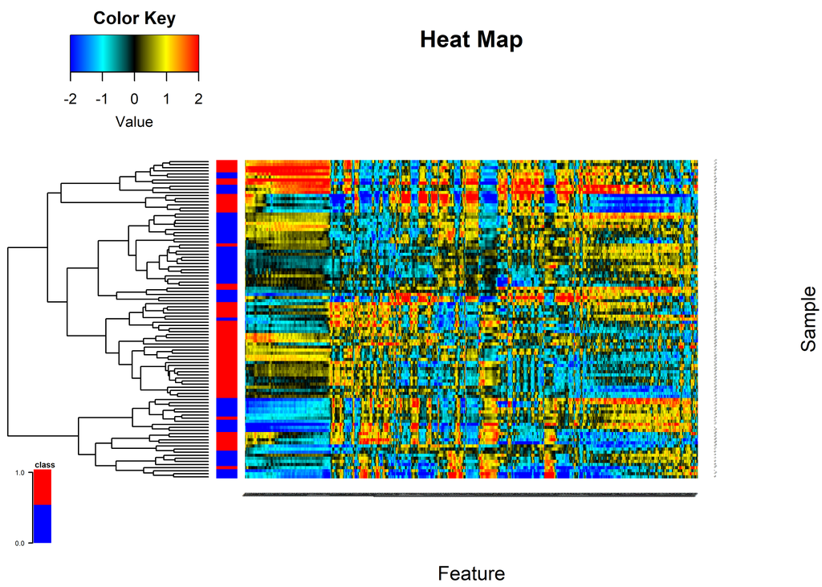

```r
if (!largeSet)
{

  hm <- heatMaps(data=dataframe,
                 Outcome=outcome,
                 Scale=TRUE,
                 hCluster = "row",
                 xlab="Feature",
                 ylab="Sample",
                 srtCol=45,
                 srtRow=45,
                 cexCol=cexheat,
                 cexRow=cexheat
                 )
  par(op)
}
```

#### 1.4.0.1 Correlation Matrix of the Data

The heat map of the data

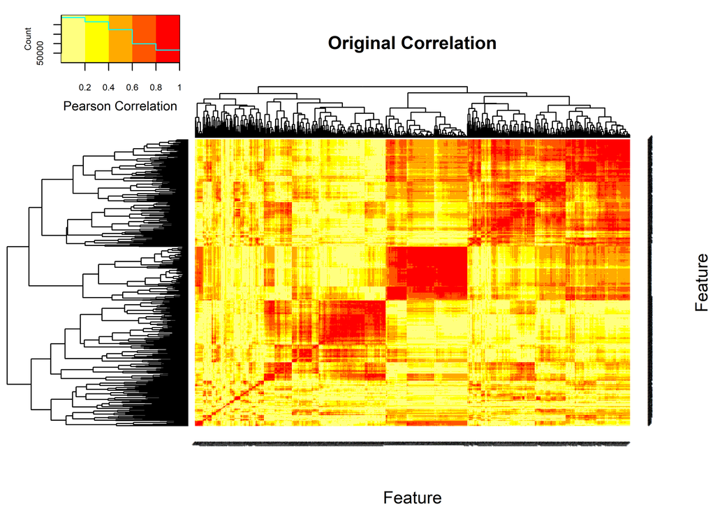

```r
if (!largeSet)
{

  par(cex=0.6,cex.main=0.85,cex.axis=0.7)
  #cormat <- Rfast::cora(as.matrix(dataframe[,varlist]),large=TRUE)
  cormat <- cor(dataframe[,varlist],method="pearson")
  cormat[is.na(cormat)] <- 0
  gplots::heatmap.2(abs(cormat),
                    trace = "none",
  #                  scale = "row",
                    mar = c(5,5),
                    col=rev(heat.colors(5)),
                    main = "Original Correlation",
                    cexRow = cexheat,
                    cexCol = cexheat,
                     srtCol=45,
                     srtRow=45,
                    key.title=NA,
                    key.xlab="Pearson Correlation",
                    xlab="Feature", ylab="Feature")
  diag(cormat) <- 0
  print(max(abs(cormat)))
}
```

[1] 0.999085

## 1.5 The decorrelation

```r
DEdataframe <- IDeA(dataframe,verbose=TRUE,thr=thro)
```

```
#>
#>  Included: 890 , Uni p: 0.02778901 , Uncorrelated Base: 13 , Outcome-Driven Size: 0 , Base Size: 13
#>
#>
```

```r
 1 <R=0.999,w=  1,N=  464>, Top: 70( 9 )[ 1 : 70 Fa= 69 : 0.975 ]( 69 , 297 , 0 ),<|>Tot Used: 366 , Added: 297 , Zero Std: 0 , Max Cor: 0.997
 2 <R=0.997,w=  1,N=  464>, Top: 34( 4 )[ 1 : 34 Fa= 99 : 0.973 ]( 33 , 47 , 69 ),<|>Tot Used: 439 , Added: 47 , Zero Std: 0 , Max Cor: 0.990
 3 <R=0.990,w=  1,N=  464>, Top: 44( 1 )[ 1 : 44 Fa= 120 : 0.970 ]( 43 , 47 , 99 ),<|>Tot Used: 500 , Added: 47 , Zero Std: 0 , Max Cor: 0.982
 4 <R=0.982,w=  1,N=  464>, Top: 37( 1 )[ 1 : 37 Fa= 138 : 0.966 ]( 37 , 38 , 120 ),<|>Tot Used: 545 , Added: 38 , Zero Std: 0 , Max Cor: 0.966
 5 <R=0.966,w=  2,N=  349>, Top: 94( 4 )[ 1 : 94 Fa= 181 : 0.933 ]( 90 , 152 , 138 ),<|>Tot Used: 679 , Added: 152 , Zero Std: 0 , Max Cor: 0.982
 6 <R=0.982,w=  2,N=  349>, Top: 21( 1 )[ 1 : 21 Fa= 191 : 0.941 ]( 20 , 28 , 181 ),<|>Tot Used: 710 , Added: 28 , Zero Std: 0 , Max Cor: 0.957
 7 <R=0.957,w=  3,N=  337>, Top: 84( 5 )[ 1 : 84 Fa= 226 : 0.879 ]( 79 , 156 , 191 ),<|>Tot Used: 791 , Added: 156 , Zero Std: 0 , Max Cor: 0.950
 8 <R=0.950,w=  3,N=  337>, Top: 36( 1 )[ 1 : 36 Fa= 239 : 0.875 ]( 35 , 48 , 226 ),<|>Tot Used: 823 , Added: 48 , Zero Std: 0 , Max Cor: 0.926
 9 <R=0.926,w=  3,N=  337>, Top: 31( 1 )[ 1 : 31 Fa= 246 : 0.863 ]( 30 , 31 , 239 ),<|>Tot Used: 833 , Added: 31 , Zero Std: 0 , Max Cor: 0.879
 10 <R=0.879,w=  4,N=  231>, Top: 63( 4 )[ 1 : 63 Fa= 261 : 0.800 ]( 56 , 102 , 246 ),<|>Tot Used: 859 , Added: 102 , Zero Std: 0 , Max Cor: 0.892
 11 <R=0.892,w=  4,N=  231>, Top: 12( 1 )[ 1 : 12 Fa= 263 : 0.800 ]( 12 , 31 , 261 ),<|>Tot Used: 865 , Added: 31 , Zero Std: 0 , Max Cor: 0.862
 12 <R=0.862,w=  4,N=  231>, Top: 5( 1 )[ 1 : 5 Fa= 267 : 0.800 ]( 5 , 7 , 263 ),<|>Tot Used: 870 , Added: 7 , Zero Std: 0 , Max Cor: 0.801
 13 <R=0.801,w=  5,N=    2>, Top: 1( 1 )[ 1 : 1 Fa= 267 : 0.800 ]( 1 , 1 , 267 ),<|>Tot Used: 870 , Added: 1 , Zero Std: 0 , Max Cor: 0.799
 14 <R=0.799,w=  6,N=    0>
 [ 14 ], 0.7983765 Decor Dimension: 870 . Cor to Base: 296 , ABase: 8 , Outcome Base: 0
varlistc <- colnames(DEdataframe)[colnames(DEdataframe) != outcome]

pander::pander(sum(apply(dataframe[,varlist],2,var)))
```

*902*

```r
pander::pander(sum(apply(DEdataframe[,varlistc],2,var)))
```

*130*

```r
pander::pander(entropy(discretize(unlist(dataframe[,varlist]), 256)))
```

*4.95*

```r
pander::pander(entropy(discretize(unlist(DEdataframe[,varlistc]), 256)))
```

*3.91*

### 1.5.1 The decorrelation matrix

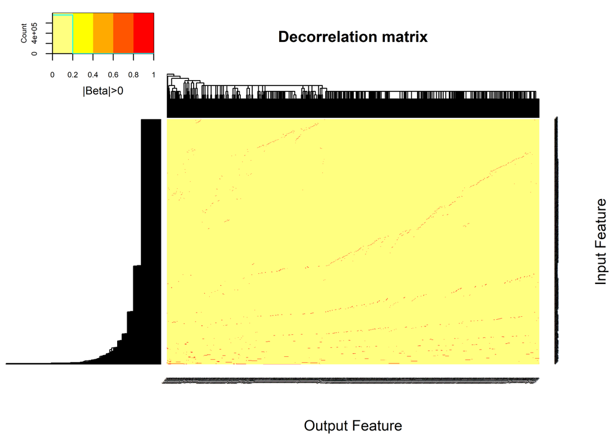

```r
if (!largeSet)
{

  par(cex=0.6,cex.main=0.85,cex.axis=0.7)

  UPSTM <- attr(DEdataframe,"UPSTM")

  gplots::heatmap.2(1.0*(abs(UPSTM)>0),
                    trace = "none",
                    mar = c(5,5),
                    col=rev(heat.colors(5)),
                    main = "Decorrelation matrix",
                    cexRow = cexheat,
                    cexCol = cexheat,
                   srtCol=45,
                   srtRow=45,
                    key.title=NA,
                    key.xlab="|Beta|>0",
                    xlab="Output Feature", ylab="Input Feature")

  par(op)
}
```

## 1.6 The heatmap of the decorrelated data

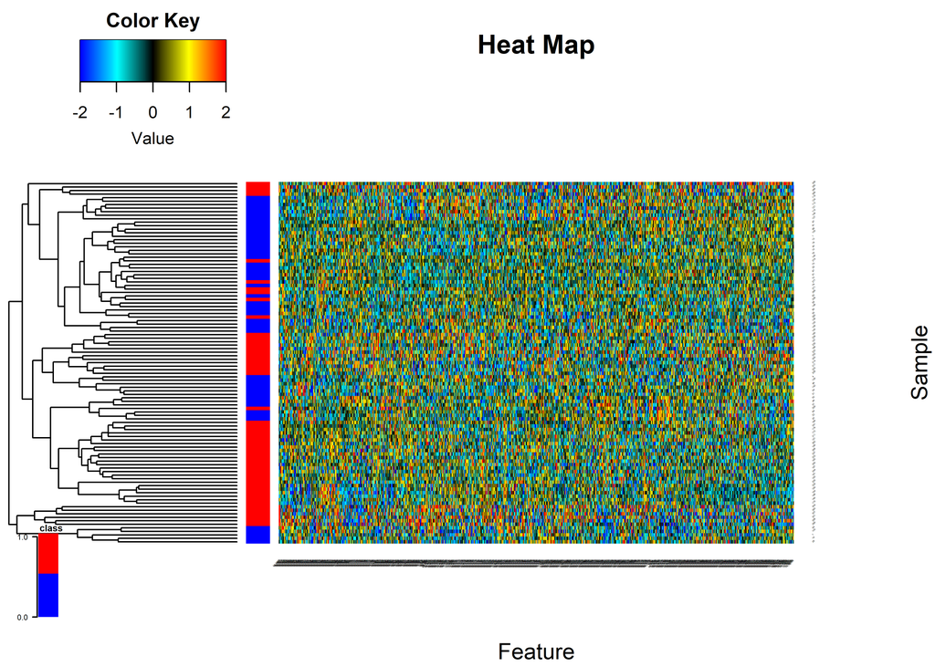

```r
if (!largeSet)
{

  hm <- heatMaps(data=DEdataframe,
                 Outcome=outcome,
                 Scale=TRUE,
                 hCluster = "row",
                 cexRow = cexheat,
                 cexCol = cexheat,
                 srtCol=45,
                 srtRow=45,
                 xlab="Feature",
                 ylab="Sample")
  par(op)
}
```

## 1.7 The correlation matrix after decorrelation

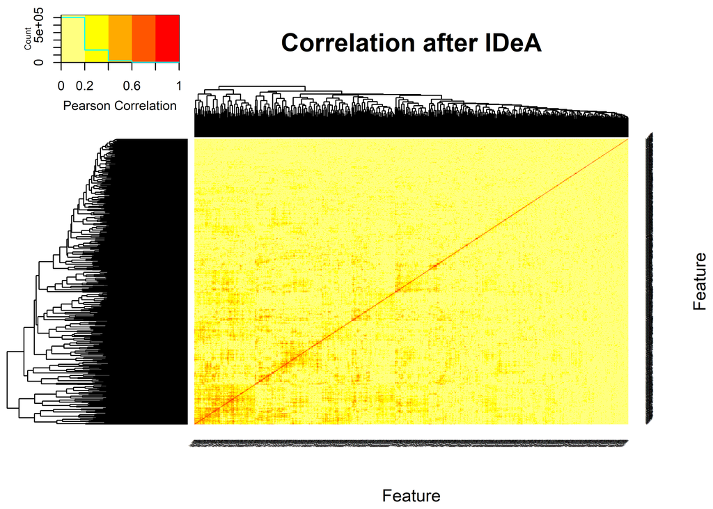

```r
if (!largeSet)
{

  cormat <- cor(DEdataframe[,varlistc],method="pearson")
  cormat[is.na(cormat)] <- 0

  gplots::heatmap.2(abs(cormat),
                    trace = "none",
                    mar = c(5,5),
                    col=rev(heat.colors(5)),
                    main = "Correlation after IDeA",
                    cexRow = cexheat,
                    cexCol = cexheat,
                     srtCol=45,
                     srtRow=45,
                    key.title=NA,
                    key.xlab="Pearson Correlation",
                    xlab="Feature", ylab="Feature")

  par(op)
  diag(cormat) <- 0
  print(max(abs(cormat)))
}
```

[1] 0.7991016

## 1.8 U-MAP Visualization of features

### 1.8.1 The UMAP based on LASSO on Raw Data

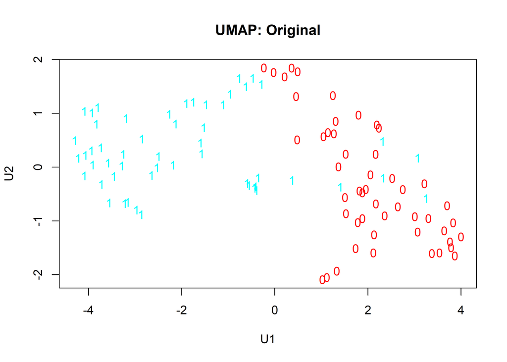

```r
classes <- unique(dataframe[,outcome])
raincolors <- rainbow(length(classes))
names(raincolors) <- classes
datasetframe.umap = umap(scale(dataframe[,varlist]),n_components=2)
plot(datasetframe.umap$layout,xlab="U1",ylab="U2",main="UMAP: Original",t='n')
text(datasetframe.umap$layout,labels=dataframe[,outcome],col=raincolors[dataframe[,outcome]+1])
```

### 1.8.2 The decorralted UMAP

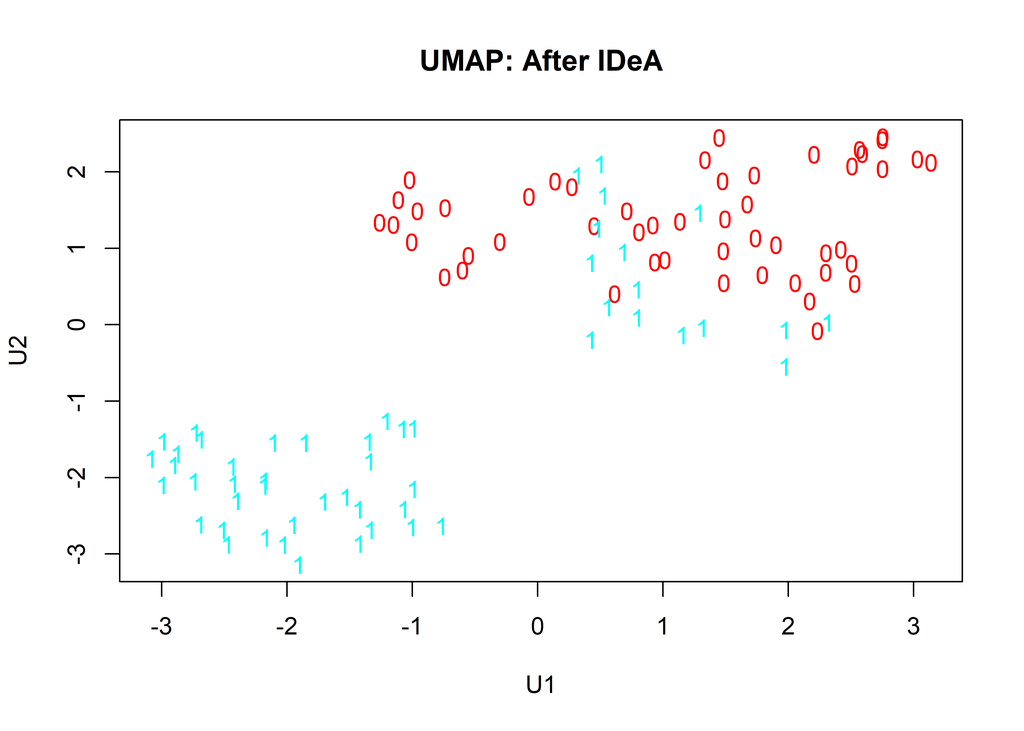

```r
datasetframe.umap = umap(scale(DEdataframe[,varlistc]),n_components=2)
plot(datasetframe.umap$layout,xlab="U1",ylab="U2",main="UMAP: After IDeA",t='n')
text(datasetframe.umap$layout,labels=DEdataframe[,outcome],col=raincolors[DEdataframe[,outcome]+1])
```

## 1.9 Univariate Analysis

### 1.9.1 Univariate

```r
univarRAW <- uniRankVar(varlist,
               paste(outcome,"~1"),
               outcome,
               dataframe,
               rankingTest="AUC")
```

100 : X641 200 : X869 300 : X1088 400 : X1293 500 : X1486  
600 : X1667 700 : X1833 800 : X1985

```r
univarDe <- uniRankVar(varlistc,
               paste(outcome,"~1"),
               outcome,
               DEdataframe,
               rankingTest="AUC",
               )
```

100 : La_X641 200 : La_X869 300 : La_X1088 400 : La_X1293 500 : La_X1486  
600 : La_X1667 700 : X1833 800 : X1985

### 1.9.2 Final Table

```r
univariate_columns <- c("caseMean","caseStd","controlMean","controlStd","controlKSP","ROCAUC")

##topfive
topvar <- c(1:length(varlist)) <= TopVariables
pander::pander(univarRAW$orderframe[topvar,univariate_columns])
```

|  | caseMean | caseStd | controlMean | controlStd | controlKSP | ROCAUC |
| --- | --- | --- | --- | --- | --- | --- |
| **X2078** | -0.753 | 0.563 | 0.486 | 0.303 | 0.988 | 0.944 |
| **X2045** | -0.666 | 0.677 | 0.641 | 0.543 | 0.595 | 0.937 |
| **X2080** | -0.711 | 0.557 | 0.464 | 0.274 | 0.985 | 0.936 |
| **X2086** | -0.720 | 0.552 | 0.458 | 0.266 | 0.802 | 0.935 |
| **X2046** | -0.656 | 0.612 | 0.520 | 0.394 | 0.926 | 0.935 |
| **X2077** | -0.673 | 0.663 | 0.548 | 0.367 | 0.935 | 0.934 |
| **X2085** | -0.789 | 0.525 | 0.393 | 0.235 | 0.801 | 0.934 |
| **X2088** | -0.714 | 0.558 | 0.456 | 0.297 | 0.899 | 0.932 |
| **X2048** | -0.627 | 0.614 | 0.545 | 0.420 | 0.750 | 0.928 |
| **X2049** | -0.598 | 0.610 | 0.552 | 0.469 | 0.904 | 0.926 |

```r
topLAvar <- univarDe$orderframe$Name[str_detect(univarDe$orderframe$Name,"La_")]
topLAvar <- unique(c(univarDe$orderframe$Name[topvar],topLAvar[1:as.integer(TopVariables/2)]))
finalTable <- univarDe$orderframe[topLAvar,univariate_columns]

theLaVar <- rownames(finalTable)[str_detect(rownames(finalTable),"La_")]

pander::pander(univarDe$orderframe[topLAvar,univariate_columns])
```

|  | caseMean | caseStd | controlMean | controlStd | controlKSP | ROCAUC |
| --- | --- | --- | --- | --- | --- | --- |
| **La_X503** | 0.1201 | 0.1424 | -0.1790 | 0.1342 | 0.544 | 0.944 |
| **X2086** | -0.7204 | 0.5517 | 0.4581 | 0.2664 | 0.802 | 0.935 |
| **La_X636** | 0.1218 | 0.1632 | -0.1838 | 0.1571 | 0.830 | 0.909 |
| **La_X598** | 0.0234 | 0.0579 | -0.0721 | 0.0498 | 0.120 | 0.903 |
| **La_X1279** | 0.1685 | 0.1527 | -0.0913 | 0.1335 | 0.998 | 0.900 |
| **La_X1318** | -0.3401 | 0.3983 | 0.3562 | 0.3904 | 0.906 | 0.893 |
| **La_X804** | 0.1789 | 0.1493 | -0.0468 | 0.1033 | 0.494 | 0.891 |
| **La_X1978** | -0.2804 | 0.3533 | 0.3172 | 0.3601 | 0.699 | 0.889 |
| **X1759** | -0.5516 | 0.6328 | 0.5444 | 0.5850 | 0.913 | 0.884 |
| **La_X1163** | 0.0301 | 0.0768 | -0.0916 | 0.0721 | 0.622 | 0.877 |

```r
dc <- getLatentCoefficients(DEdataframe)
fscores <- attr(DEdataframe,"fscore")

theSigDc <- dc[theLaVar]
names(theSigDc) <- NULL
theSigDc <- unique(names(unlist(theSigDc)))


theFormulas <- dc[rownames(finalTable)]
deFromula <- character(length(theFormulas))
names(deFromula) <- rownames(finalTable)

pander::pander(c(mean=mean(sapply(dc,length)),total=length(dc),fraction=length(dc)/(ncol(dataframe)-1)))
```

| mean | total | fraction |
| --- | --- | --- |
| 2.23 | 832 | 0.935 |

```r
allSigvars <- names(dc)



dx <- names(deFromula)[1]
for (dx in names(deFromula))
{
  coef <- theFormulas[[dx]]
  cname <- names(theFormulas[[dx]])
  names(cname) <- cname
  for (cf in names(coef))
  {
    if (cf != dx)
    {
      if (coef[cf]>0)
      {
        deFromula[dx] <- paste(deFromula[dx],
                               sprintf("+ %5.3f*%s",coef[cf],cname[cf]))
      }
      else
      {
        deFromula[dx] <- paste(deFromula[dx],
                               sprintf("%5.3f*%s",coef[cf],cname[cf]))
      }
    }
  }
}

finalTable <- rbind(finalTable,univarRAW$orderframe[theSigDc[!(theSigDc %in% rownames(finalTable))],univariate_columns])


orgnamez <- rownames(finalTable)
orgnamez <- str_remove_all(orgnamez,"La_")
finalTable$RAWAUC <- univarRAW$orderframe[orgnamez,"ROCAUC"]
finalTable$DecorFormula <- deFromula[rownames(finalTable)]
finalTable$fscores <- fscores[rownames(finalTable)]

Final_Columns <- c("DecorFormula","caseMean","caseStd","controlMean","controlStd","controlKSP","ROCAUC","RAWAUC","fscores")

finalTable <- finalTable[order(-finalTable$ROCAUC),]
pander::pander(finalTable[,Final_Columns])
```

|  | DecorFormula | caseMean | caseStd | controlMean | controlStd | controlKSP | ROCAUC | RAWAUC | fscores |
| --- | --- | --- | --- | --- | --- | --- | --- | --- | --- |
| **La_X503** | + 1.000*X503 -1.088*X510 | 0.1201 | 0.1424 | -0.1790 | 0.1342 | 0.544 | 0.944 | 0.628 | 0 |
| **X2086** |  | -0.7204 | 0.5517 | 0.4581 | 0.2664 | 0.802 | 0.935 | 0.935 | 12 |
| **La_X636** | + 1.000*X636 -1.088*X655 | 0.1218 | 0.1632 | -0.1838 | 0.1571 | 0.830 | 0.909 | 0.631 | 1 |
| **La_X598** | + 1.000*X598 -0.938*X601 -0.070*X655 | 0.0234 | 0.0579 | -0.0721 | 0.0498 | 0.120 | 0.903 | 0.574 | -2 |
| **La_X1279** | + 1.000*X1279 -0.984*X1283 | 0.1685 | 0.1527 | -0.0913 | 0.1335 | 0.998 | 0.900 | 0.561 | -1 |
| **La_X1318** | + 1.000*X1318 + 1.007*X1703 | -0.3401 | 0.3983 | 0.3562 | 0.3904 | 0.906 | 0.893 | 0.610 | -1 |
| **La_X804** | + 1.000*X804 -0.840*X833 | 0.1789 | 0.1493 | -0.0468 | 0.1033 | 0.494 | 0.891 | 0.724 | 1 |
| **La_X1978** | + 1.000*X1978 -0.823*X2004 | -0.2804 | 0.3533 | 0.3172 | 0.3601 | 0.699 | 0.889 | 0.795 | 8 |
| **X1759** |  | -0.5516 | 0.6328 | 0.5444 | 0.5850 | 0.913 | 0.884 | 0.884 | 7 |
| **La_X1163** | + 1.000*X1163 -0.984*X1165 | 0.0301 | 0.0768 | -0.0916 | 0.0721 | 0.622 | 0.877 | 0.592 | -1 |
| **X1978** | NA | -0.4487 | 0.7742 | 0.3988 | 0.7415 | 0.319 | 0.795 | 0.795 | NA |
| **X804** | NA | 0.4013 | 0.9352 | -0.2407 | 0.5605 | 0.667 | 0.724 | 0.724 | NA |
| **X833** | NA | 0.2648 | 1.1266 | -0.2308 | 0.7105 | 0.950 | 0.673 | 0.673 | NA |
| **X636** | NA | 0.3090 | 1.0567 | -0.3226 | 1.3170 | 0.338 | 0.631 | 0.631 | NA |
| **X503** | NA | 0.2564 | 0.9866 | -0.3512 | 1.1056 | 0.491 | 0.628 | 0.628 | NA |
| **X1318** | NA | -0.2114 | 1.0186 | 0.2353 | 1.2358 | 0.637 | 0.610 | 0.610 | NA |
| **X2004** | NA | -0.2044 | 0.8768 | 0.0991 | 0.8825 | 0.789 | 0.609 | 0.609 | 6 |
| **X1163** | NA | 0.2055 | 0.9321 | -0.0459 | 0.8864 | 0.461 | 0.592 | 0.592 | NA |
| **X1703** | NA | -0.1278 | 0.9406 | 0.1201 | 1.0756 | 0.618 | 0.575 | 0.575 | NA |
| **X598** | NA | 0.1956 | 1.0013 | -0.1826 | 1.2202 | 0.588 | 0.574 | 0.574 | NA |
| **X655** | NA | 0.1721 | 1.0080 | -0.1276 | 1.1973 | 0.929 | 0.561 | 0.561 | 88 |
| **X1279** | NA | 0.2029 | 1.0161 | -0.1182 | 0.8143 | 0.775 | 0.561 | 0.561 | NA |
| **X1165** | NA | 0.1783 | 0.9388 | 0.0465 | 0.9128 | 0.159 | 0.559 | 0.559 | NA |
| **X510** | NA | 0.1253 | 0.8904 | -0.1583 | 1.0546 | 0.821 | 0.553 | 0.553 | NA |
| **X601** | NA | 0.1709 | 0.9986 | -0.1084 | 1.2181 | 0.748 | 0.552 | 0.552 | NA |
| **X1283** | NA | 0.0350 | 1.0319 | -0.0273 | 0.8124 | 0.675 | 0.488 | 0.488 | NA |